# IODS course project

Yujing He

# Introduction to Open Data Science - Course Project

# Chapter 1: Start me up!

*Write a short description about the course and add a link to your GitHub repository here. This is an R Markdown (.Rmd) file so you should use R Markdown syntax.*

```r
# This is a so-called "R chunk" where you can write R code.

date()
```

```
## [1] "Sat Nov 18 18:11:24 2023"
```

The text continues here.

## 1. Some thoughts about this course

*e.g., How are you feeling right now? What do you expect to learn? Where did you hear about the course?*

As an R beginners, I feel this course is very friendly. Both the instructions from the teacher and the book are clear enough for me to understand and move on easily. The learning curve looks smooth, and the instructions are also encouraging. All these provide confidence for a beginner. I have been impressed by the versatile and powerful usage of R, so I want to add it into my research tool box although my research currently does not involve it (potential in the future if I own the skill). In other words, learning R is my interest or hobby at this moment. It is always good to learn some fresh things in my spare time - R is the one recently! I heard about this course from my colleague who usually can make many impressive graphs with statistical data. He became really skillful in operating R and realizing many functions after one-year learning, starting from this course one year ago. His feedback on this course and the learning outcomes really encouraged me to get engaged into R from this course.

## 2. Reflection on the book and the Exercise 1

*How did it work as a “crash course” on modern R tools and using RStudio? Which were your favorite topics? Which topics were most difficult? Some other comments on the book and our new approach of getting started with R Markdown etc.?*

This book is clear, well instructional, and encouraging for an R beginner. I enjoy learning the part of data wrangling and visualization, which is easily accessible and readable. My favorite character of R is the instant feedback after executing the commands, no matter right or wrong. This is what a researcher is eager for, but seldom meets in the academic career after making some efforts. However, I could feel challenging in the data analysis which needs specialized knowledge in statistics to interpret the R outcomes. It could be easy to run the analysis functions but not easy to understand the meaning of the results. Therefore, more things should be learned when I move on to the data analysis in R. The book has provided so many instructions to go through and practice, which are clear to follow. I think it is very nice and enough for me to get start with R. Just need to spend time in it.

## 3. Link to my GitHub repository

https://github.com/YujingTuuli/IODS-project

## 4. Describe the work I have done this week and summarize my learning

Following the detail instruction in “Start me up”, I set up the technical platforms needed in this course, including R, RStudio, and GitHub. Following the teacher’s instruction, I got the know how to push the updated script to the GitHub. Then I started the learning of R with the book “R for Health Data Science”, and the corresponding exercise 1. In this week, I finished the learning of Chapter 1-5 in the book, which was a heavy and time-consuming task, but rewarding! In addition, I read the recommended Part 1 of the textbook “MABS4IODS”, and the two webinars on RStudio and GitHub.

# Chapter 2: Regression and model validation

*Describe the work you have done this week and summarize your learning.*

- Describe your work and results clearly.
- Assume the reader has an introductory course level understanding of writing and reading R code as well as statistical methods.
- Assume the reader has no previous knowledge of your data or the more advanced methods you are using.

```r
date()
```

```
## [1] "Sat Nov 18 18:11:24 2023"
```

*Data analysis assignment*

## 1 Read the data

Read the students2014 data into R and explore the structure and the dimensions of the data

```r
students2014 <- read.table("https://raw.githubusercontent.com/KimmoVehkalahti/Helsinki-Open-Data-Science/master/datasets/learning2014.txt", sep=",", header=TRUE)

dim(students2014)
```

```
## [1] 166   7
```

```r
str(students2014)
```

```
## 'data.frame':    166 obs. of  7 variables:
##  $ gender  : chr  "F" "M" "F" "M" ...
##  $ age     : int  53 55 49 53 49 38 50 37 37 42 ...
##  $ attitude: num  3.7 3.1 2.5 3.5 3.7 3.8 3.5 2.9 3.8 2.1 ...
##  $ deep    : num  3.58 2.92 3.5 3.5 3.67 ...
##  $ stra    : num  3.38 2.75 3.62 3.12 3.62 ...
##  $ surf    : num  2.58 3.17 2.25 2.25 2.83 ...
##  $ points  : int  25 12 24 10 22 21 21 31 24 26 ...
```

Description: The data set consists of 166 observations of 7 variables. The data present the information of gender, age, attitude, learning points of 166 students, and their responses to the questions related to deep, surface and strategic learning.

## 2 Grapical overview with a plot matrix

Show a graphical overview of the data and show summaries of the variables in the data. Describe and interpret the outputs, commenting on the distributions of the variables and the relationships between them.

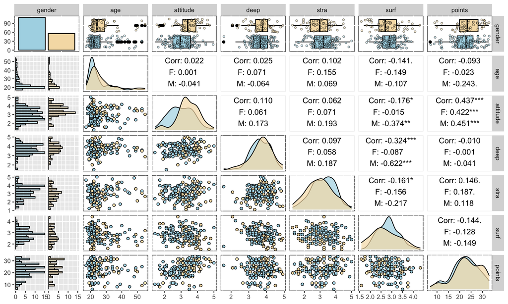

```r
library(ggplot2)
library(GGally)
# For making a nicer plot
my_lower <- function(data, mapping, ...) {
  ggplot(data = data, mapping=mapping) +
    geom_point(..., alpha=1, pch = 21, color ="black") +
    theme(
      panel.background = element_rect(fill = "white", color = "black")
    )
}

my_diag <- function(data, mapping, ...) {
  ggplot(data = data, mapping=mapping) +
    geom_density(..., alpha=0.7,  color ="black") +
    theme(
      panel.background = element_rect(fill = "white", color = "black")
    )
}

my_discrete <- function(data, mapping, ...) {
  ggplot(data = data, mapping=mapping) +
    geom_bar(..., alpha=1,  color ="black") +
    theme(
      panel.background = element_rect(fill = "white", color = "black")
    )
}

my_upper_combo<- function(data, mapping, ...) {
  ggplot(data = data, mapping=mapping) +
    geom_boxplot(...,alpha=1, color ="black") +
    geom_jitter(...,alpha = 0.5, width = 0.25, size = 1, pch = 21, color = "black")+
    theme(
      panel.background = element_rect(fill = "white", color = "black")
    )
}

# Plot
p <- ggpairs(students2014,
             mapping = aes(col = gender, fill = gender, alpha = 0.7),
             lower = list(
               continuous = my_lower,
               combo = wrap("facethist", bins = 20, color = "black")
               ),
             diag = list(
               continuous = my_diag,
               discrete =  my_discrete
             ),
             upper = list(
               combo = my_upper_combo,
               continuous = wrap("cor", color = "black")
             )
             )+
  scale_fill_manual(values = c("lightblue", "wheat"))+
  scale_color_manual(values = c("lightblue", "wheat"))


# Print the plot
p
```

```r
# Summaries of the variables in the data
summary(students2014)
```

```
##     gender               age           attitude          deep
##  Length:166         Min.   :17.00   Min.   :1.400   Min.   :1.583
##  Class :character   1st Qu.:21.00   1st Qu.:2.600   1st Qu.:3.333
##  Mode  :character   Median :22.00   Median :3.200   Median :3.667
##                     Mean   :25.51   Mean   :3.143   Mean   :3.680
##                     3rd Qu.:27.00   3rd Qu.:3.700   3rd Qu.:4.083
##                     Max.   :55.00   Max.   :5.000   Max.   :4.917
##       stra            surf           points
##  Min.   :1.250   Min.   :1.583   Min.   : 7.00
##  1st Qu.:2.625   1st Qu.:2.417   1st Qu.:19.00
##  Median :3.188   Median :2.833   Median :23.00
##  Mean   :3.121   Mean   :2.787   Mean   :22.72
##  3rd Qu.:3.625   3rd Qu.:3.167   3rd Qu.:27.75
##  Max.   :5.000   Max.   :4.333   Max.   :33.00
```

Description: Most of the numeric variables in the data are relatively normally distributed, except for the age which is mostly distributed around twenties. Female are about two times more than males in frequency. Within the variables, attitude towards statistics seems to be most strongly correlated with exam points (r=0.437).

## 3 Fit a regression model

Choose three variables as explanatory variables and fit a regression model where exam points is the target (dependent, outcome) variable. Show a summary of the fitted model and comment and interpret the results. Explain and interpret the statistical test related to the model parameters. If an explanatory variable in your model does not have a statistically significant relationship with the target variable, remove the variable from the model and fit the model again without it.

```r
# Choose attitude, stra, and surf as the three explanatory variables because they have highest (absolute) correlation with the target variable exam points, according to the plot matrix.
model1 <- lm(points ~ attitude + stra + surf, data = students2014)

# Print out the summary of the first model
summary(model1)
```

```
##
## Call:
## lm(formula = points ~ attitude + stra + surf, data = students2014)
##
## Residuals:
##      Min       1Q   Median       3Q      Max
## -17.1550  -3.4346   0.5156   3.6401  10.8952
##
## Coefficients:
##             Estimate Std. Error t value Pr(>|t|)
## (Intercept)  11.0171     3.6837   2.991  0.00322 **
## attitude      3.3952     0.5741   5.913 1.93e-08 ***
## stra          0.8531     0.5416   1.575  0.11716
## surf         -0.5861     0.8014  -0.731  0.46563
## ---
## Signif. codes:  0 '***' 0.001 '**' 0.01 '*' 0.05 '.' 0.1 ' ' 1
##
## Residual standard error: 5.296 on 162 degrees of freedom
## Multiple R-squared:  0.2074, Adjusted R-squared:  0.1927
## F-statistic: 14.13 on 3 and 162 DF,  p-value: 3.156e-08
```

```r
# Remove the unfit variables and new fitted regression model
model2 <- lm(points ~ attitude, data = students2014)

# Print out the summary of the fitted model
summary(model2)
```

```
##
## Call:
## lm(formula = points ~ attitude, data = students2014)
##
## Residuals:
##      Min       1Q   Median       3Q      Max
## -16.9763  -3.2119   0.4339   4.1534  10.6645
##
## Coefficients:
##             Estimate Std. Error t value Pr(>|t|)
## (Intercept)  11.6372     1.8303   6.358 1.95e-09 ***
## attitude      3.5255     0.5674   6.214 4.12e-09 ***
## ---
## Signif. codes:  0 '***' 0.001 '**' 0.01 '*' 0.05 '.' 0.1 ' ' 1
##
## Residual standard error: 5.32 on 164 degrees of freedom
## Multiple R-squared:  0.1906, Adjusted R-squared:  0.1856
## F-statistic: 38.61 on 1 and 164 DF,  p-value: 4.119e-09
```

Description: “Attitude” was the single significant predictor in the model. Other two variables entered model–“stra” and “surf”–had p-values 0.12 and 0.47, respectively. Therefore, the model was re-fitted with “attitude” alone, producing a final model that explains 19.06% (R squared = 0.1906) of the variance of the response (exam points).

## 4 Interpret the fitted model

Using a summary of your fitted model, explain the relationship between the chosen explanatory variables and the target variable (interpret the model parameters). Explain and interpret the multiple R-squared of the model.

```r
summary(model2)
```

```
##
## Call:
## lm(formula = points ~ attitude, data = students2014)
##
## Residuals:
##      Min       1Q   Median       3Q      Max
## -16.9763  -3.2119   0.4339   4.1534  10.6645
##
## Coefficients:
##             Estimate Std. Error t value Pr(>|t|)
## (Intercept)  11.6372     1.8303   6.358 1.95e-09 ***
## attitude      3.5255     0.5674   6.214 4.12e-09 ***
## ---
## Signif. codes:  0 '***' 0.001 '**' 0.01 '*' 0.05 '.' 0.1 ' ' 1
##
## Residual standard error: 5.32 on 164 degrees of freedom
## Multiple R-squared:  0.1906, Adjusted R-squared:  0.1856
## F-statistic: 38.61 on 1 and 164 DF,  p-value: 4.119e-09
```

Description: The resulting model shows attitude is a meaningful predictor for exam points, specifically:

```
- a. With a unit of increase in attitude, the exam will increase by 3.5 points

- b. When the effect of attitude is held as none, the average exam points is 11.637. In other words, students would be expected to have 11.637 points in the exam if attitude did not influence at all.

- c. The model predicts a fairly small proportion (19%) of change in exam points. In other words, attitude is not a good enough predictor for exam points, even though its role in influencing the results should be recognized. Random error or other factors should have played roles in the exam points.
```

## 5 Diagnostic plots

Produce the following diagnostic plots: Residuals vs Fitted values, Normal QQ-plot and Residuals vs Leverage. Explain the assumptions of the model and interpret the validity of those assumptions based on the diagnostic plots.

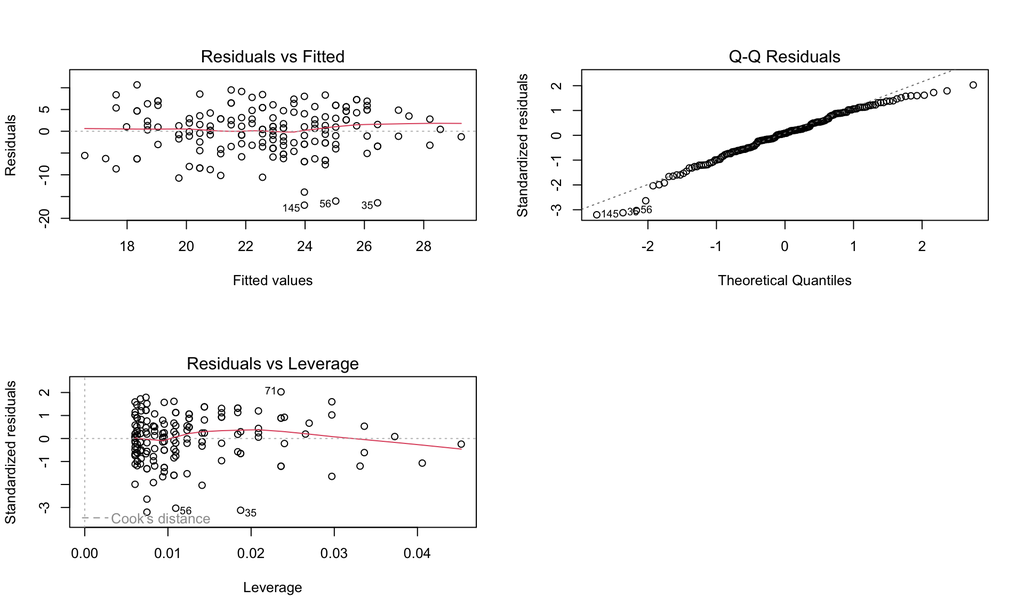

```r
par(mfrow = c(2,2))
plot(model2, which = c(1,2,5))
```

[output not shown]

# Chapter 3: Logistic Regression

```r
date()
```

```
## [1] "Sat Nov 18 18:11:27 2023"
```

## 1 Read the data

```r
library(dplyr)
library(readr)
# read the data
alc <- read.table("https://raw.githubusercontent.com/KimmoVehkalahti/Helsinki-Open-Data-Science/master/datasets/alc.csv", sep=",", header=TRUE)
# print out the names of the variables
colnames(alc)
```

```
##  [1] "school"     "sex"        "age"        "address"    "famsize"
##  [6] "Pstatus"    "Medu"       "Fedu"       "Mjob"       "Fjob"
## [11] "reason"     "guardian"   "traveltime" "studytime"  "schoolsup"
## [16] "famsup"     "activities" "nursery"    "higher"     "internet"
## [21] "romantic"   "famrel"     "freetime"   "goout"      "Dalc"
## [26] "Walc"       "health"     "failures"   "paid"       "absences"
## [31] "G1"         "G2"         "G3"         "alc_use"    "high_use"
```

```r
dim(alc)
```

```
## [1] 370  35
```

```r
glimpse(alc)
```

```
## Rows: 370
## Columns: 35
## $ school     <chr> "GP", "GP", "GP", "GP", "GP", "GP", "GP", "GP", "GP", "GP",…
## $ sex        <chr> "F", "F", "F", "F", "F", "M", "M", "F", "M", "M", "F", "F",…
## $ age        <int> 18, 17, 15, 15, 16, 16, 16, 17, 15, 15, 15, 15, 15, 15, 15,…
## $ address    <chr> "U", "U", "U", "U", "U", "U", "U", "U", "U", "U", "U", "U",…
## $ famsize    <chr> "GT3", "GT3", "LE3", "GT3", "GT3", "LE3", "LE3", "GT3", "LE…
## $ Pstatus    <chr> "A", "T", "T", "T", "T", "T", "T", "A", "A", "T", "T", "T",…
## $ Medu       <int> 4, 1, 1, 4, 3, 4, 2, 4, 3, 3, 4, 2, 4, 4, 2, 4, 4, 3, 3, 4,…
## $ Fedu       <int> 4, 1, 1, 2, 3, 3, 2, 4, 2, 4, 4, 1, 4, 3, 2, 4, 4, 3, 2, 3,…
## $ Mjob       <chr> "at_home", "at_home", "at_home", "health", "other", "servic…
## $ Fjob       <chr> "teacher", "other", "other", "services", "other", "other", …
## $ reason     <chr> "course", "course", "other", "home", "home", "reputation", …
## $ guardian   <chr> "mother", "father", "mother", "mother", "father", "mother",…
## $ traveltime <int> 2, 1, 1, 1, 1, 1, 1, 2, 1, 1, 1, 3, 1, 2, 1, 1, 1, 3, 1, 1,…
```

[output cut: 22 more lines]

This data set includes the information of **370** students’ background, achievement, and alcohol consumption in two Portuguese schools. There are **35** variables in the data, including student grades, demographic, social and school related features, as well as students’ performance in Mathematics (mat) and Portuguese language (por). The data was collected by using school reports and questionnaires.

## 2 Hypothesis

*The purpose of your analysis is to study the relationships between high/low alcohol consumption and some of the other variables in the data. To do this, choose 4 interesting variables in the data and for each of them, present your personal hypothesis about their relationships with alcohol consumption.*

Based on my everyday observation and some research reports about teenagers’ alcohol consumpution, I would like to choose family relationships (“famrel”), number of school absences (“absences”), weekly study time (“studytime”) and frequency of going out with friends (“goout”) as candidate indicators to predict the alcohol consumption. Htpothesis: a student belongs to the group of high alcohol consumption if he or she (1) has low quality family relationship; (2) more frequency of school absences; (3) less weekly study time; and (4) more frequency of going out with friends.

## 3 The distribution of the chosen variables and their relationships with alcohol consumption

*Numerically and graphically explore the distributions of your chosen variables and their relationships with alcohol consumption (use for example cross-tabulations, bar plots and box plots). Comment on your findings and compare the results of your exploration to your previously stated hypotheses.*

### 3.1 The distribution of the chosen variables

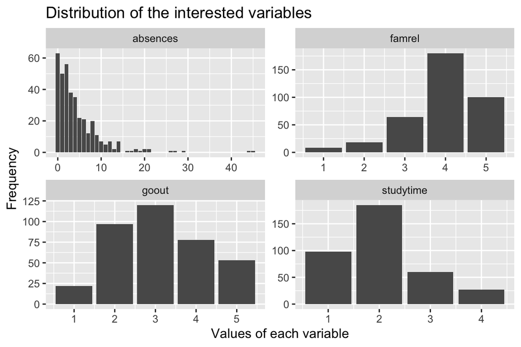

```r
library(ggplot2)
library(tidyr)

alc |>
  select(absences, studytime, famrel, goout) |>
  pivot_longer(everything(),
               names_to = "variable",
               values_to = "value") |>
  ggplot(aes(x = value))+
  facet_wrap(~variable, scales = "free")+
  geom_bar()+
  labs(title = "Distribution of the interested variables",
       x  = "Values of each variable",
       y = "Frequency")
```

### 3.2 The relationships between interesting variables and alcohol consumption

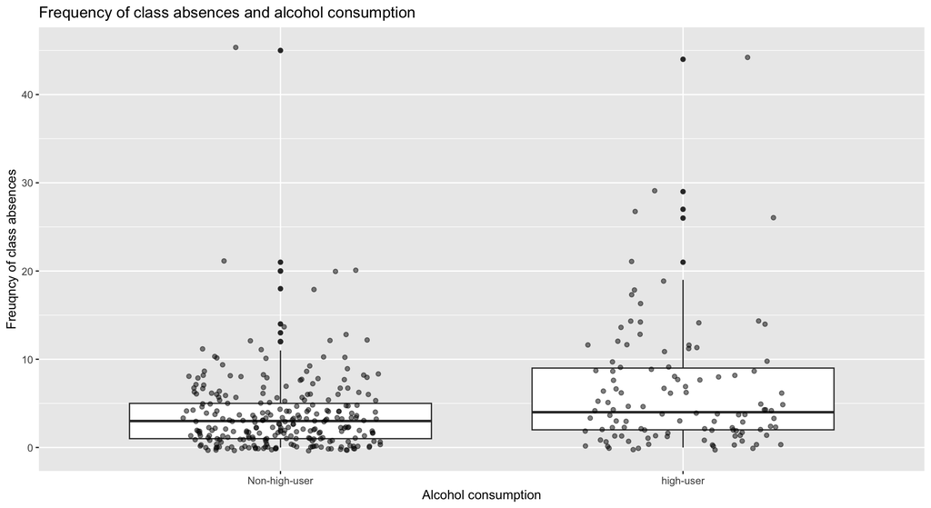

```r
# The relationship between students' absences of class and alcohol consumption (box plot for numerical~categorical variables)
p1 <- alc |>
  ggplot(aes(x = high_use, y = absences)) +
  geom_boxplot() +
  geom_jitter(width=0.25, alpha=0.5)+
  labs(x = "Alcohol consumption",
       y = "Freuqncy of class absences",
       title =
         "Frequency of class absences and alcohol consumption")+
  scale_x_discrete(labels = c("FALSE" = "Non-high-user",
                              "TRUE" = "high-user"))
p1
```

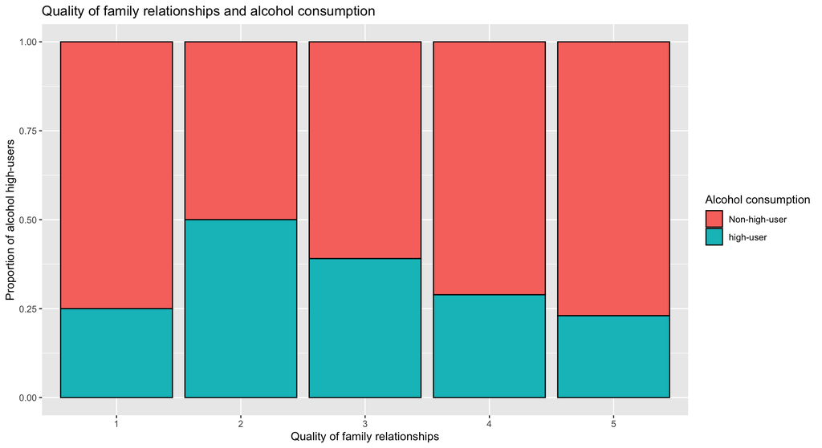

```r
# The relationship between quality of family relation and alcohol consumption (bar plot for categorical variables)
p2 <- alc |>
  ggplot(aes(x = factor(famrel), fill = high_use)) +
  geom_bar(position = "fill", color = "black") +
  labs(x = "Quality of family relationships",
       y = "Proportion of alcohol high-users",
       title =
         "Quality of family relationships and alcohol consumption")+
  guides(fill=guide_legend("Alcohol consumption"))+
  scale_fill_discrete(labels = c("FALSE" = "Non-high-user",
                                 "TRUE" = "high-user"))
p2
```

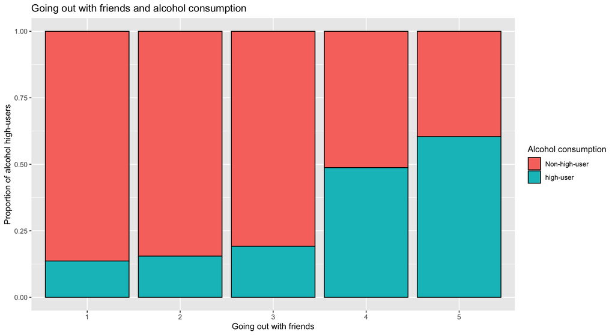

```r
# The relationship between going out with friends and alcohol consumption (bar plot for categorical variables)
p3 <- alc |>
  ggplot(aes(x = factor(goout), fill = high_use)) +
  geom_bar(position = "fill", color = "black") +
  labs(x = "Going out with friends",
       y = "Proportion of alcohol high-users",
       title =
         "Going out with friends and alcohol consumption")+
  guides(fill=guide_legend("Alcohol consumption"))+
  scale_fill_discrete(labels = c("FALSE" = "Non-high-user",
                                 "TRUE" = "high-user"))
p3
```

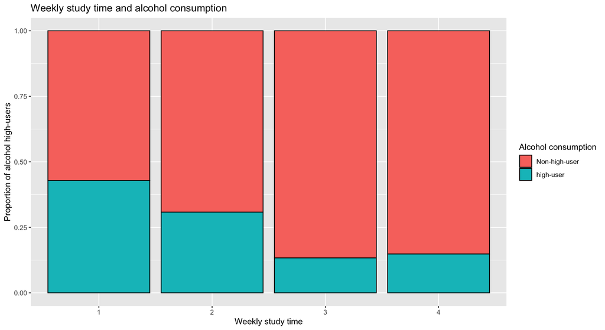

```r
# The relationship between weekly study time and alcohol consumption (bar plot for categorical variables)
p4 <- alc |>
  ggplot(aes(x = factor(studytime), fill = high_use)) +
  geom_bar(position = "fill", color = "black") +
  labs(x = "Weekly study time",
       y = "Proportion of alcohol high-users",
       title =
         "Weekly study time and alcohol consumption")+
  guides(fill=guide_legend("Alcohol consumption"))+
  scale_fill_discrete(labels = c("FALSE" = "Non-high-user",
                                 "TRUE" = "high-user"))
p4
```

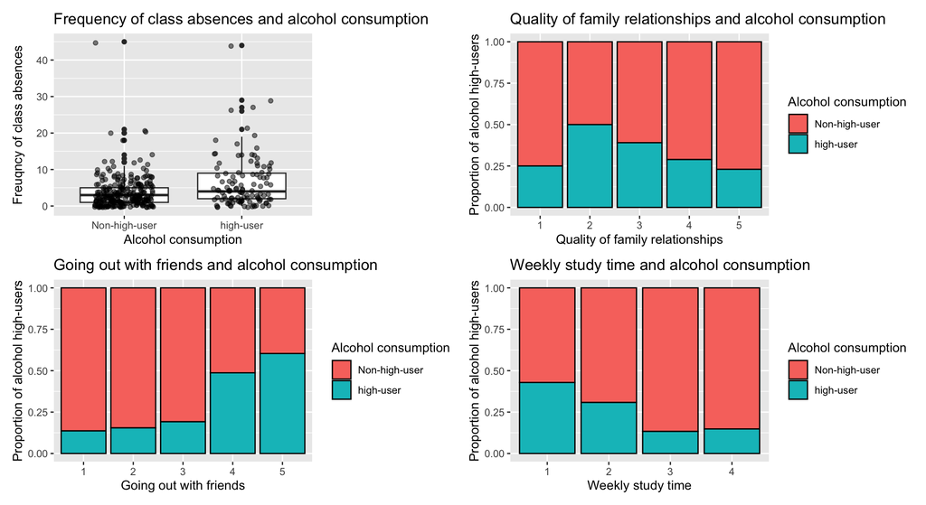

```r
# combining four plots together
library(patchwork)
p1 + p2 + p3 + p4
```

## 4 Logistic regression

*Use logistic regression to statistically explore the relationship between your chosen variables and the binary high/low alcohol consumption variable as the target variable. Present and interpret a summary of the fitted model. Present and interpret the coefficients of the model as odds ratios and provide confidence intervals for them. Interpret the results and compare them to your previously stated hypothesis. Hint: If your model includes factor variables, see for example the RHDS book or the first answer of this stack exchange thread on how R treats and how you should interpret these variables in the model output (or use some other resource to study this).*

```r
# Fit the model base on the original hypothesis
model <- glm(high_use ~ absences + famrel + goout + studytime, data = alc, family = "binomial")
summary(model)
```

```
##
## Call:
## glm(formula = high_use ~ absences + famrel + goout + studytime,
##     family = "binomial", data = alc)
##
## Coefficients:
##             Estimate Std. Error z value Pr(>|z|)
## (Intercept) -1.15221    0.71444  -1.613 0.106798
## absences     0.06655    0.02192   3.036 0.002394 **
## famrel      -0.35898    0.13796  -2.602 0.009266 **
## goout        0.75990    0.12143   6.258 3.91e-10 ***
## studytime   -0.57194    0.16963  -3.372 0.000747 ***
## ---
## Signif. codes:  0 '***' 0.001 '**' 0.01 '*' 0.05 '.' 0.1 ' ' 1
##
## (Dispersion parameter for binomial family taken to be 1)
##
##     Null deviance: 452.04  on 369  degrees of freedom
## Residual deviance: 370.36  on 365  degrees of freedom
## AIC: 380.36
##
## Number of Fisher Scoring iterations: 4
```

```r
# Important parameters
OR <- coef(model)
CI <- confint(model)
ORCI <- cbind(OR, CI)
print(ORCI, digits = 1)
```

```
##                OR 2.5 % 97.5 %
## (Intercept) -1.15 -2.57   0.24
## absences     0.07  0.02   0.11
## famrel      -0.36 -0.63  -0.09
## goout        0.76  0.53   1.01
## studytime   -0.57 -0.92  -0.25
```

## 5 Predicted probabilities and cross tabulation

*Using the variables which, according to your logistic regression model, had a statistical relationship with high/low alcohol consumption, explore the predictive power of you model. Provide a 2x2 cross tabulation of predictions versus the actual values and optionally display a graphic visualizing both the actual values and the predictions. Compute the total proportion of inaccurately classified individuals (= the training error) and comment on all the results. Compare the performance of the model with performance achieved by some simple guessing strategy.*

```r
# Explore the predictive power of the model
probabilities <- predict(model, type = "response")
# Add the predicted probabilities to 'alc'
alc <- mutate(alc, probability = probabilities)
# Use the probabilities to make a prediction of high_use
alc <- mutate(alc, prediction = probability > 0.5)
# See the last ten original classes, predicted probabilities, and class predictions
select(alc, absences, famrel, goout, studytime, high_use, probability, prediction) %>% tail(10)
```

```
##     absences famrel goout studytime high_use probability prediction
## 361        3      4     3         2    FALSE  0.22224385      FALSE
## 362        0      4     2         1    FALSE  0.16242879      FALSE
## 363        7      5     3         1     TRUE  0.31573116      FALSE
## 364        1      5     3         3    FALSE  0.08975198      FALSE
## 365        6      4     3         1    FALSE  0.38200795      FALSE
## 366        2      5     2         3    FALSE  0.04697548      FALSE
## 367        2      4     4         2    FALSE  0.36371174      FALSE
## 368        3      1     1         2    FALSE  0.15505370      FALSE
## 369        4      2     5         1     TRUE  0.83529411       TRUE
## 370        2      4     1         1     TRUE  0.09388808      FALSE
```

```r
# Tabulate the target variable versus the predictions
table(high_use = alc$high_use, prediction = alc$prediction)%>%
  addmargins
```

```
##         prediction
## high_use FALSE TRUE Sum
##    FALSE   233   26 259
##    TRUE     63   48 111
##    Sum     296   74 370
```

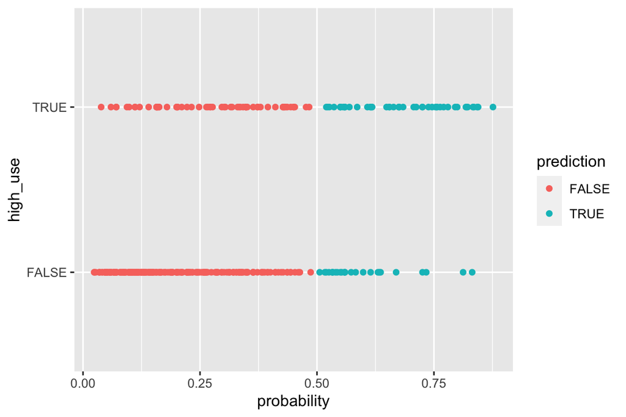

```r
# Display a graphic visualizing actual high_use and predictions
p5 <- ggplot(alc, aes(x = probability, y = high_use, col = prediction))+
  geom_point()
p5
```

```r
# tabulate the target variable versus the predictions
table(high_use = alc$high_use, prediction = alc$prediction)%>%
  prop.table()%>%
  addmargins()%>%
  print(digits = 2)
```

```
##         prediction
## high_use FALSE TRUE  Sum
##    FALSE  0.63 0.07 0.70
##    TRUE   0.17 0.13 0.30
##    Sum    0.80 0.20 1.00
```

## 6 10-fold cross-validation (bonus)

*Bonus: Perform 10-fold cross-validation on your model. Does your model have better test set performance (smaller prediction error using 10-fold cross-validation) compared to the model introduced in the Exercise Set (which had about 0.26 error). Could you find such a model?*

```r
# Define a loss function (mean prediction error)
loss_func <- function(class, prob) {
  n_wrong <- abs(class - prob) > 0.5
  mean(n_wrong)
}
# Call loss_func to compute the average number of wrong predictions in the (training) data
loss_func(class = alc$high_use, prob = alc$probability)
```

```
## [1] 0.2405405
```

```r
# K-fold cross-validation
library(boot)
set.seed(1)
cv <- cv.glm(data = alc, cost = loss_func, glmfit = model, K = 10)
# average number of wrong predictions in the cross validation
delta.percent <- paste0((cv$delta[1]|> round(4))*100, "%")
```

The prediction error rate is 24%, outperforming the model in Exercise Set 3, which had about 26% error. According to the result of 10 fold cross-validation, the model has an average error rate of 23.51%, a bit lower than the results from training model.

## 7 The relationship between prediction error and number of predictors (super bonus)

*Perform cross-validation to compare the performance of different logistic regression models (= different sets of predictors). Start with a very high number of predictors and explore the changes in the training and testing errors as you move to models with less predictors. Draw a graph displaying the trends of both training and testing errors by the number of predictors in the model.*